# Untitled

Francisco Javier Polo Martinez

19/2/2022

> https://www.tmwr.org/ames.html https://www.tmwr.org/explain.html

```r
#####################################################
###################### https://www.tmwr.org/ames.html ###############################
#####################################################

# install.packages("modeldata")
library(modeldata)

data(ames, package = "modeldata")


# Función   Paquete Código
# lda() MASA    predecir(objeto)
# glm() estadísticas    predict(object, type = "response")
# gbm() gbm predict(object, type = "response", n.trees)
# mda() mda predict(object, type = "posterior")
# rpart()   rpart   predict(object, type = "prob")
# varios    RWeka   predict(objeto, tipo = "probabilidad")
# logitboost()  LogitBoost  predict(object, type = "raw", nIter)
# pamr.train()  pamr    pamr.predict(objeto, tipo = "posterior")
```

```r
dim(ames)
```

```
## [1] 2930   74
```

Comencemos con el resultado que queremos predecir: el último precio de venta de la casa

```r
library(tidymodels)
```

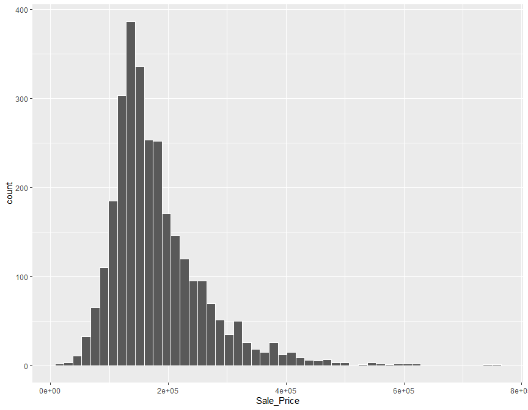

```r
tidymodels_prefer()

ggplot(ames, aes(x = Sale_Price)) +
  geom_histogram(bins = 50, col= "white")
```

Los datos están sesgados a la derecha; hay casas más baratas que caras. El precio medio de venta fue de $ 160,000 y la casa más cara fue de $ 755,000. Al modelar este resultado, se puede argumentar que el precio debe transformarse en logarítmicamente. Las ventajas de hacer esto son que no se predecirían casas con precios de venta negativos y que los errores en la predicción de casas caras no tendrán una influencia indebida en el modelo. Además, desde una perspectiva estadística, una transformada logarítmica también puede estabilizar la varianza de una manera que hace que la inferencia sea más legítima.

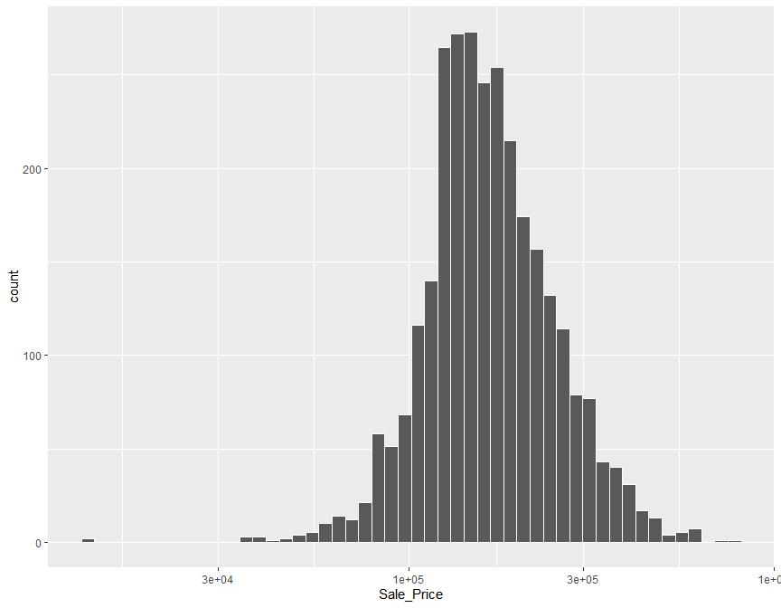

```r
ggplot(ames, aes(x = Sale_Price)) +
  geom_histogram(bins = 50, col= "white") +
  scale_x_log10()
```

Si bien no es perfecto, esto probablemente resultará en mejores modelos que el uso de los datos no transformados.

Las unidades de los coeficientes del modelo pueden ser más difíciles de interpretar, al igual que las medidas de rendimiento. Por ejemplo, el error cuadrático medio raíz (RMSE) es una métrica de rendimiento común que se utiliza en los modelos de regresión. Utiliza la diferencia entre los valores observados y predichos en sus cálculos. Si el precio de venta está en la escala logarítmica, estas diferencias (es decir, los residuos) también se encuentran en unidades logarítmicas. Por esta razón, puede ser difícil entender la calidad de un modelo cuyo RMSE es de 0,15 unidades logarítmicas.

A pesar de estos inconvenientes, los modelos utilizados en este libro utilizan la transformación logarítmica para este resultado. A partir de este momento, la columna de resultados se registra previamente en el marco de datos:ames

```r
ames <- ames %>% mutate(Sale_Price = log10(Sale_Price))
```

Otro aspecto importante de estos datos para nuestro modelado son sus ubicaciones geográficas. Esta información espacial está contenida en los datos de dos maneras: una etiqueta cualitativa, así como datos cuantitativos de longitud y latitud.

Supongamos que asignamos el 80% de los datos al conjunto de entrenamiento y el 20% restante para las pruebas. El método más común es utilizar un muestreo aleatorio simple. El paquete rsample tiene herramientas para hacer divisiones de datos como esta; la función fue creada para este propósito.

```r
library(tidymodels)
tidymodels_prefer()

# Set the random number stream using `set.seed()` so that the results can be
# reproduced later.
set.seed(123)

# Save the split information for an 80/20 split of the data
ames_split <- initial_split(ames, prop = 0.80)
ames_split
```

```
## <Analysis/Assess/Total>
## <2344/586/2930>
```

```r
ames_train <- training(ames_split)
ames_test  <- testing(ames_split)

dim(ames_train)
```

```
## [1] 2344   74
```

```r
set.seed(123)
ames_split <- initial_split(ames, prop = 0.80, strata = Sale_Price)
ames_train <- training(ames_split)
ames_test  <-  testing(ames_split)

dim(ames_train)
```

```
## [1] 2342   74
```

```r
# install.packages("rstanarm")
library(rstanarm)
linear_reg() %>% set_engine("lm")
```

```
## Linear Regression Model Specification (regression)
##
## Computational engine: lm
```

```r
linear_reg() %>% set_engine("glmnet")
```

```
## Linear Regression Model Specification (regression)
##
## Computational engine: glmnet
```

```r
linear_reg() %>% set_engine("stan")
```

```
## Linear Regression Model Specification (regression)
##
## Computational engine: stan
```

```r
linear_reg() %>% set_engine("lm") %>% translate()
```

```
## Linear Regression Model Specification (regression)
##
## Computational engine: lm
##
## Model fit template:
## stats::lm(formula = missing_arg(), data = missing_arg(), weights = missing_arg())
```

```r
linear_reg(penalty = 1) %>% set_engine("glmnet") %>% translate()
```

```
## Linear Regression Model Specification (regression)
##
## Main Arguments:
##   penalty = 1
##
## Computational engine: glmnet
##
## Model fit template:
## glmnet::glmnet(x = missing_arg(), y = missing_arg(), weights = missing_arg(),
##     family = "gaussian")
```

```r
linear_reg() %>% set_engine("stan") %>% translate()
```

```
## Linear Regression Model Specification (regression)
##
## Computational engine: stan
##
## Model fit template:
## rstanarm::stan_glm(formula = missing_arg(), data = missing_arg(),
##     weights = missing_arg(), family = stats::gaussian, refresh = 0)
```

Veamos cómo predecir el precio de venta de las casas en los datos de Ames en función de solo la longitud y la latitud:

```r
lm_model <-
  linear_reg() %>%
  set_engine("lm")

lm_form_fit <-
  lm_model %>%
  # Recall that Sale_Price has been pre-logged
  fit(Sale_Price ~ Longitude + Latitude, data = ames_train)

lm_xy_fit <-
  lm_model %>%
  fit_xy(
    x = ames_train %>% select(Longitude, Latitude),
    y = ames_train %>% pull(Sale_Price)
  )

lm_form_fit
```

```
## parsnip model object
##
## Fit time:  0ms
##
## Call:
## stats::lm(formula = Sale_Price ~ Longitude + Latitude, data = data)
##
## Coefficients:
## (Intercept)    Longitude     Latitude
##    -300.251       -2.013        2.782
```

```r
lm_xy_fit
```

```
## parsnip model object
##
## Fit time:  0ms
##
## Call:
## stats::lm(formula = ..y ~ ., data = data)
##
## Coefficients:
## (Intercept)    Longitude     Latitude
##    -300.251       -2.013        2.782
```

```r
rand_forest(trees = 1000, min_n = 5) %>%
  set_engine("ranger") %>%
  set_mode("regression") %>%
  translate()
```

```
## Random Forest Model Specification (regression)
##
## Main Arguments:
##   trees = 1000
##   min_n = 5
##
## Computational engine: ranger
##
## Model fit template:
## ranger::ranger(x = missing_arg(), y = missing_arg(), case.weights = missing_arg(),
##     num.trees = 1000, min.node.size = min_rows(~5, x), num.threads = 1,
##     verbose = FALSE, seed = sample.int(10^5, 1))
```

```r
rand_forest(trees = 1000, min_n = 5) %>%
  set_engine("ranger") %>%
  set_mode("regression") %>%
  translate()
```

```
## Random Forest Model Specification (regression)
##
## Main Arguments:
##   trees = 1000
##   min_n = 5
##
## Computational engine: ranger
##
## Model fit template:
## ranger::ranger(x = missing_arg(), y = missing_arg(), case.weights = missing_arg(),
##     num.trees = 1000, min.node.size = min_rows(~5, x), num.threads = 1,
##     verbose = FALSE, seed = sample.int(10^5, 1))
```

Una vez que el modelo está creado y encajado, podemos usar los resultados de varias maneras; es posible que deseemos trazar, imprimir o examinar de otro modo la salida del modelo. Varias cantidades se almacenan en un objeto de modelo, incluido el modelo ajustado. Esto se puede encontrar en un elemento llamado , que se puede devolver utilizando la función:fitextract_fit_engine()

```r
lm_form_fit %>% extract_fit_engine()
```

```
##
## Call:
## stats::lm(formula = Sale_Price ~ Longitude + Latitude, data = data)
##
## Coefficients:
## (Intercept)    Longitude     Latitude
##    -300.251       -2.013        2.782
```

Se pueden aplicar métodos normales a este objeto, como imprimir, trazar, etc.:

```r
lm_form_fit %>% extract_fit_engine() %>% vcov()
```

```
##             (Intercept)     Longitude      Latitude
## (Intercept)  212.620590  1.6113032179 -1.4686377363
## Longitude      1.611303  0.0168165968 -0.0008694728
## Latitude      -1.468638 -0.0008694728  0.0330018995
```

Un problema con algunos métodos existentes en la base R es que los resultados se almacenan de una manera que puede no ser la más útil. Por ejemplo, el método para objetos se puede utilizar para imprimir los resultados del ajuste del modelo, incluida una tabla con valores de parámetros, sus estimaciones de incertidumbre y valores p. Estos resultados particulares también se pueden guardar:summary()lm

```r
model_res <-
  lm_form_fit %>%
  extract_fit_engine() %>%
  summary()
```

```r
param_est <- coef(model_res)
class(param_est)
```

```
## [1] "matrix" "array"
```

```r
param_est
```

```
##                Estimate Std. Error   t value     Pr(>|t|)
## (Intercept) -300.250929 14.5815154 -20.59120 1.022609e-86
## Longitude     -2.013413  0.1296788 -15.52615 8.126177e-52
## Latitude       2.781713  0.1816642  15.31239 1.639312e-50
```

Hay algunas cosas a tener en cuenta sobre este resultado. Primero, el objeto es una matriz numérica. Es probable que esta estructura de datos se haya elegido principalmente ya que todos los resultados calculados son numéricos y un objeto de matriz se almacena de manera más eficiente que un marco de datos. Esta elección probablemente se hizo a fines de la década de 1970, cuando la eficiencia computacional era extremadamente crítica. En segundo lugar, los datos no numéricos (las etiquetas de los coeficientes) están contenidos en los nombres de las filas. Mantener las etiquetas de parámetros como nombres de fila es muy coherente con las convenciones en el idioma S original.

Hay métodos para convertir muchos tipos de objetos de modelo en una estructura ordenada. Por ejemplo, el uso del método en el modelo lineal produce:tidy()

```r
tidy(lm_form_fit)
```

| term | estimate | std.error | statistic | p.value |
| --- | --- | --- | --- | --- |
| (Intercept) | -300.250929 | 14.5815154 | -20.59120 | 1.022609e-86 |
| Longitude | -2.013413 | 0.1296788 | -15.52615 | 8.126177e-52 |
| Latitude | 2.781713 | 0.1816642 | 15.31239 | 1.639312e-50 |

```r
ames_test_small <- ames_test %>% slice(1:5)
predict(lm_form_fit, new_data = ames_test_small)
```

| .pred |
| --- |
| 5.223697 |
| 5.221967 |
| 5.284242 |
| 5.239113 |
| 5.314692 |

```r
ames_test_small %>%
  select(Sale_Price) %>%
  bind_cols(predict(lm_form_fit, ames_test_small)) %>%

  bind_cols(predict(lm_form_fit, ames_test_small, type = "pred_int"))
```

| Sale_Price | .pred | .pred_lower | .pred_upper |
| --- | --- | --- | --- |
| 5.021189 | 5.223697 | 4.907039 | 5.540355 |
| 5.235528 | 5.221967 | 4.905310 | 5.538625 |
| 5.278525 | 5.284242 | 4.967563 | 5.600922 |
| 5.060698 | 5.239113 | 4.922441 | 5.555785 |
| 5.596808 | 5.314692 | 4.997995 | 5.631388 |

Para la segunda regla de predicción tidymodels, los nombres de columna predecibles para diferentes tipos de predicciones se muestran en la Tabla 6.4.

```r
tree_model <-
  decision_tree(min_n = 2) %>%
  set_engine("rpart") %>%
  set_mode("regression")

tree_fit <-
  tree_model %>%
  fit(Sale_Price ~ Longitude + Latitude, data = ames_train)

ames_test_small %>%
  select(Sale_Price) %>%
  bind_cols(predict(tree_fit, ames_test_small))
```

| Sale_Price | .pred |
| --- | --- |
| 5.021189 | 5.149002 |
| 5.235528 | 5.149002 |
| 5.278525 | 5.309862 |
| 5.060698 | 5.149002 |
| 5.596808 | 5.522254 |

Puede llegar a ser tedioso escribir muchas especificaciones de modelo, o recordar cómo escribir el código para generarlas. El paquete de parsnip incluye un complemento RStudio12 eso puede ayudar. Elija este complemento en el menú de la barra de herramientas Complementos o ejecute el código:

```r
parsnip_addin()
```

```
##
## Listening on http://127.0.0.1:7639
```

> https://www.tidymodels.org/find/mlp_nnet_spec <-

```r
# parsniplogistic_reg_glm_spec <-
#   logistic_reg() %>%
#   set_engine('glm')
#
# logistic_reg_glm_spec <-
#   logistic_reg() %>%
#   set_engine('glm')
#
# svm_poly_kernlab_spec <-
#   svm_poly(cost = tune(), degree = tune(), scale_factor = tune(), margin = tune()) %>%
#   set_engine('kernlab') %>%
#   set_mode('classification')
```

```r
  # mlp(hidden_units = tune(), penalty = tune(), epochs = tune()) %>%
  # set_engine('nnet') %>%
  # set_mode('classification')
```

```r
library(tidymodels)  # Includes the workflows package
tidymodels_prefer()

lm_model <-
  linear_reg() %>%
  set_engine("lm")
```

```r
lm_wflow <-
  workflow() %>%
  add_model(lm_model)

lm_wflow
```

```
## == Workflow ====================================================================
## Preprocessor: None
## Model: linear_reg()
##
## -- Model -----------------------------------------------------------------------
## Linear Regression Model Specification (regression)
##
## Computational engine: lm
```

```r
lm_wflow <-
  lm_wflow %>%
  add_formula(Sale_Price ~ Longitude + Latitude)

lm_wflow
```

```
## == Workflow ====================================================================
## Preprocessor: Formula
## Model: linear_reg()
##
## -- Preprocessor ----------------------------------------------------------------
## Sale_Price ~ Longitude + Latitude
##
## -- Model -----------------------------------------------------------------------
## Linear Regression Model Specification (regression)
##
## Computational engine: lm
```

```r
lm_fit <- fit(lm_wflow, ames_train)
lm_fit
```

```
## == Workflow [trained] ==========================================================
## Preprocessor: Formula
## Model: linear_reg()
##
## -- Preprocessor ----------------------------------------------------------------
## Sale_Price ~ Longitude + Latitude
##
## -- Model -----------------------------------------------------------------------
##
## Call:
## stats::lm(formula = ..y ~ ., data = data)
##
## Coefficients:
## (Intercept)    Longitude     Latitude
##    -300.251       -2.013        2.782
```

También podemos en el flujo de trabajo ajustado:predict()

```r
predict(lm_fit, ames_test %>% slice(1:10))
```

| .pred |
| --- |
| 5.223697 |
| 5.221967 |
| 5.284242 |
| 5.239113 |
| 5.314692 |
| 5.309498 |
| 5.313128 |
| 5.298222 |
| 5.296110 |
| 5.291188 |

Tanto el modelo como el preprocesador se pueden quitar o actualizar:

```r
lm_fit %>% update_formula(Sale_Price ~ Longitude)
```

```
## == Workflow ====================================================================
## Preprocessor: Formula
## Model: linear_reg()
##
## -- Preprocessor ----------------------------------------------------------------
## Sale_Price ~ Longitude
##
## -- Model -----------------------------------------------------------------------
## Linear Regression Model Specification (regression)
##
## Computational engine: lm
```

**ADICIÓN DE VARIABLES SIN PROCESAR AL FLUJO DE TRABAJO**

Hay otra interfaz para pasar datos al modelo, la función que utiliza una sintaxis similar a dplyr para elegir variables. La función tiene dos argumentos principales: y . Estos utilizan un enfoque de selección similar al back-end tidyselect de los paquetes tidyverse para capturar múltiples selectores utilizando .add_variables()outcomespredictorsc()

```r
lm_wflow <-
  lm_wflow %>%
  remove_formula() %>%
  add_variables(outcome = Sale_Price, predictors = c(Longitude, Latitude))
lm_wflow
```

```
## == Workflow ====================================================================
## Preprocessor: Variables
## Model: linear_reg()
##
## -- Preprocessor ----------------------------------------------------------------
## Outcomes: Sale_Price
## Predictors: c(Longitude, Latitude)
##
## -- Model -----------------------------------------------------------------------
## Linear Regression Model Specification (regression)
##
## Computational engine: lm
```

Los predictores también podrían haberse especificado utilizando un selector más general, como

```r
library(dplyr)

# predictors = c(ends_with("tude"))
```

```r
# predictors = everything()
```

```r
fit(lm_wflow, ames_train)
```

```
## == Workflow [trained] ==========================================================
## Preprocessor: Variables
## Model: linear_reg()
##
## -- Preprocessor ----------------------------------------------------------------
## Outcomes: Sale_Price
## Predictors: c(Longitude, Latitude)
##
## -- Model -----------------------------------------------------------------------
##
## Call:
## stats::lm(formula = ..y ~ ., data = data)
##
## Coefficients:
## (Intercept)    Longitude     Latitude
##    -300.251       -2.013        2.782
```

digamos que queremos centrarnos en las diferentes formas en que se representa la ubicación de la casa en los datos de Ames. Podemos crear un conjunto de fórmulas que capturen estos predictores:

```r
library(lme4)
location <- list(
  longitude = Sale_Price ~ Longitude,
  latitude = Sale_Price ~ Latitude,
  coords = Sale_Price ~ Longitude + Latitude,
  neighborhood = Sale_Price ~ Neighborhood
)
```

Estas representaciones se pueden cruzar con uno o más modelos utilizando la función. Solo usaremos la especificación del modelo lineal anterior para demostrar:workflow_set()

```r
library(workflowsets)
location_models <- workflow_set(preproc = location, models = list(lm = lm_model))
location_models
```

| wflow_id | info | option | result |
| --- | --- | --- | --- |
| longitude_lm |  |  |  |
| latitude_lm |  |  |  |
| coords_lm |  |  |  |
| neighborhood_lm |  |  |  |

```r
location_models$info[[1]]
```

| workflow | preproc | model | comment |
| --- | --- | --- | --- |
|  | formula | linear_reg |  |

```r
extract_workflow(location_models, id = "coords_lm")
```

```
## == Workflow ====================================================================
## Preprocessor: Formula
## Model: linear_reg()
##
## -- Preprocessor ----------------------------------------------------------------
## Sale_Price ~ Longitude + Latitude
##
## -- Model -----------------------------------------------------------------------
## Linear Regression Model Specification (regression)
##
## Computational engine: lm
```

vamos a crear ajustes de modelo para cada fórmula y guardarlos en una nueva columna llamada . Usaremos operaciones básicas de dplyr y purrr:fit

```r
location_models <-
   location_models %>%
   mutate(fit = map(info, ~ fit(.x$workflow[[1]], ames_train)))
location_models
```

| wflow_id | info | option | result | fit |
| --- | --- | --- | --- | --- |
| longitude_lm |  |  |  |  |
| latitude_lm |  |  |  |  |
| coords_lm |  |  |  |  |
| neighborhood_lm |  |  |  |  |

```r
location_models$fit[[1]]
```

```
## == Workflow [trained] ==========================================================
## Preprocessor: Formula
## Model: linear_reg()
##
## -- Preprocessor ----------------------------------------------------------------
## Sale_Price ~ Longitude
##
## -- Model -----------------------------------------------------------------------
##
## Call:
## stats::lm(formula = ..y ~ ., data = data)
##
## Coefficients:
## (Intercept)    Longitude
##     -176.46        -1.94
```

**resumen**

```r
library(tidymodels)
data(ames)

ames <- mutate(ames, Sale_Price = log10(Sale_Price))

set.seed(123)
ames_split <- initial_split(ames, prop = 0.80, strata = Sale_Price)
ames_train <- training(ames_split)
ames_test  <-  testing(ames_split)

lm_model <- linear_reg() %>% set_engine("lm")

lm_wflow <-
  workflow() %>%
  add_model(lm_model) %>%
  add_formula(Sale_Price ~ Longitude + Latitude)

lm_fit <- fit(lm_wflow, ames_train)

lm_fit
```

```
## == Workflow [trained] ==========================================================
## Preprocessor: Formula
## Model: linear_reg()
##
## -- Preprocessor ----------------------------------------------------------------
## Sale_Price ~ Longitude + Latitude
##
## -- Model -----------------------------------------------------------------------
##
## Call:
## stats::lm(formula = ..y ~ ., data = data)
##
## Coefficients:
## (Intercept)    Longitude     Latitude
##    -300.251       -2.013        2.782
```

```r
lm(Sale_Price ~ Neighborhood + log10(Gr_Liv_Area) + Year_Built + Bldg_Type, data = ames)
```

```
##
## Call:
## lm(formula = Sale_Price ~ Neighborhood + log10(Gr_Liv_Area) +
##     Year_Built + Bldg_Type, data = ames)
##
## Coefficients:
##                                         (Intercept)
##                                          -0.8551717
##                           NeighborhoodCollege_Creek
##                                           0.0135485
##                                NeighborhoodOld_Town
##                                          -0.0289607
##                                 NeighborhoodEdwards
##                                          -0.0493174
##                                NeighborhoodSomerset
##                                           0.0499653
##                      NeighborhoodNorthridge_Heights
##                                           0.1335758
##                                 NeighborhoodGilbert
##                                          -0.0337334
##                                  NeighborhoodSawyer
##                                          -0.0042779
##                          NeighborhoodNorthwest_Ames
##                                           0.0004589
##                             NeighborhoodSawyer_West
##                                          -0.0174582
##                                NeighborhoodMitchell
##                                           0.0004695
##                               NeighborhoodBrookside
##                                          -0.0110205
##                                NeighborhoodCrawford
##                                           0.0914254
##                  NeighborhoodIowa_DOT_and_Rail_Road
##                                          -0.0839821
##                              NeighborhoodTimberland
##                                           0.0604062
##                              NeighborhoodNorthridge
##                                           0.0845868
##                             NeighborhoodStone_Brook
##                                           0.1459657
```

[output cut: 19 more lines]

```
##                                           0.2229230
##                                NeighborhoodLandmark
##                                          -0.0119925
##                                  log10(Gr_Liv_Area)
##                                           0.6343996
##                                          Year_Built
##                                           0.0020678
##                                   Bldg_TypeTwoFmCon
##                                          -0.0312306
##                                     Bldg_TypeDuplex
##                                          -0.1038443
##                                      Bldg_TypeTwnhs
##                                          -0.0968859
##                                     Bldg_TypeTwnhsE
##                                          -0.0414929
```

Cuando se ejecuta esta función, los datos se convierten de un marco de datos a una matriz de diseño numérico (también llamada matriz de modelo) y luego se utiliza el método de mínimos cuadrados para estimar parámetros.

El precio de venta se define como el resultado, mientras que el vecindario, la superficie habitable bruta, el año de construcción y las variables de tipo de edificio se definen como predictores.

Se aplica una transformación logarítmica al predictor de área de vida bruta.

Las columnas de tipo de vecindario y edificio se convierten de un formato no numérico a un formato numérico (ya que los mínimos cuadrados requieren predictores numéricos).

```r
library(tidymodels) # Includes the recipes package
tidymodels_prefer()

simple_ames <-
  recipe(Sale_Price ~ Neighborhood + Gr_Liv_Area + Year_Built + Bldg_Type,
         data = ames_train) %>%
  step_log(Gr_Liv_Area, base = 10) %>%
  step_dummy(all_nominal_predictors())
simple_ames
```

```
## Recipe
##
## Inputs:
##
##       role #variables
##    outcome          1
##  predictor          4
##
## Operations:
##
## Log transformation on Gr_Liv_Area
## Dummy variables from all_nominal_predictors()
```

La llamada a con una fórmula le dice a la receta los roles de las variables (por ejemplo, predictor, resultado). Solo utiliza los datos para determinar los tipos de datos de las columnas.recipe()ames_train

step_log() declara que se debe transformar en el registro.Gr_Liv_Area

step_dummy() se utiliza para especificar qué variables deben convertirse de un formato cualitativo a un formato cuantitativo, en este caso, utilizando variables ficticias o indicadoras. Un indicador o variable ficticia es una variable numérica binaria (una columna de unos y ceros) que codifica información cualitativa

```r
# lm_wflow %>%
#   add_recipe(simple_ames)
```

¡Eso no funcionó! Solo podemos tener un método de preprocesamiento a la vez, por lo que debemos eliminar el preprocesador existente antes de agregar la receta.

```r
lm_wflow <-
  lm_wflow %>%
  remove_variables() %>%
  add_recipe(simple_ames)
lm_wflow
```

```
## == Workflow ====================================================================
## Preprocessor: Recipe
## Model: linear_reg()
##
## -- Preprocessor ----------------------------------------------------------------
## 2 Recipe Steps
##
## * step_log()
## * step_dummy()
##
## -- Model -----------------------------------------------------------------------
## Linear Regression Model Specification (regression)
##
## Computational engine: lm
```

Vamos a estimar tanto la receta como el modelo usando una simple llamada a:fit()

```r
lm_fit <- fit(lm_wflow, ames_train)
```

```r
predict(lm_fit, ames_test %>% slice(1:10))
```

| .pred |
| --- |
| 5.072611 |
| 5.173625 |
| 5.274878 |
| 5.082677 |
| 5.510075 |
| 5.436557 |
| 5.563720 |
| 5.353954 |
| 5.242631 |
| 5.526987 |

Si necesitamos el objeto o receta del modelo desnudo, existen funciones que pueden recuperarlos:extract_*

```r
lm_fit %>%
  extract_recipe(estimated = TRUE)
```

```
## Recipe
##
## Inputs:
##
##       role #variables
##    outcome          1
##  predictor          4
##
## Training data contained 2342 data points and no missing data.
##
## Operations:
##
## Log transformation on Gr_Liv_Area [trained]
## Dummy variables from Neighborhood, Bldg_Type [trained]
```

```r
lm_fit %>%
  extract_fit_parsnip() %>%
  tidy() %>%
  slice(1:5)
```

| term | estimate | std.error | statistic | p.value |
| --- | --- | --- | --- | --- |
| (Intercept) | -0.681820406 | 0.2277165872 | -2.994162 | 2.781230e-03 |
| Gr_Liv_Area | 0.624909786 | 0.0139592131 | 44.766835 | 1.358955e-315 |
| Year_Built | 0.001993628 | 0.0001154501 | 17.268313 | 6.191588e-63 |
| Neighborhood_College_Creek | 0.016662367 | 0.0080727067 | 2.064037 | 3.912571e-02 |
| Neighborhood_Old_Town | -0.035661502 | 0.0084434960 | -4.223547 | 2.498182e-05 |

Los datos se pasan a las recetas en diferentes etapas.

```r
simple_ames <-
  recipe(Sale_Price ~ Neighborhood + Gr_Liv_Area + Year_Built + Bldg_Type,
         data = ames_train) %>%
  step_log(Gr_Liv_Area, base = 10) %>%
  step_other(Neighborhood, threshold = 0.01) %>%
  step_dummy(all_nominal_predictors())
simple_ames
```

```
## Recipe
##
## Inputs:
##
##       role #variables
##    outcome          1
##  predictor          4
##
## Operations:
##
## Log transformation on Gr_Liv_Area
## Collapsing factor levels for Neighborhood
## Dummy variables from all_nominal_predictors()
```

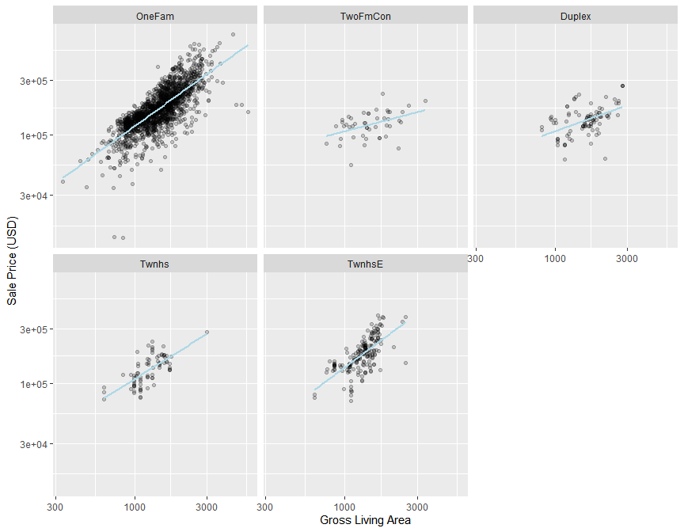

```r
ggplot(ames_train, aes(x = Gr_Liv_Area, y = 10^Sale_Price)) +
  geom_point(alpha = .2) +
  facet_wrap(~ Bldg_Type) +
  geom_smooth(method = lm, formula = y ~ x, se = FALSE, color = "lightblue") +
  scale_x_log10() +
  scale_y_log10() +
  labs(x = "Gross Living Area", y = "Sale Price (USD)")
```

```r
simple_ames <-
  recipe(Sale_Price ~ Neighborhood + Gr_Liv_Area + Year_Built + Bldg_Type,
         data = ames_train) %>%
  step_log(Gr_Liv_Area, base = 10) %>%
  step_other(Neighborhood, threshold = 0.01) %>%
  step_dummy(all_nominal_predictors()) %>%
  # Gr_Liv_Area is on the log scale from a previous step
  step_interact( ~ Gr_Liv_Area:starts_with("Bldg_Type_") )
```

Se pueden especificar interacciones adicionales en esta fórmula separándolas por . También tenga en cuenta que la receta solo utilizará interacciones entre diferentes variables; si la fórmula utiliza , este término será ignorado.+var_1:var_1

Supongamos que, en una receta, aún no hubiéramos hecho variables ficticias para los tipos de construcción. Sería inapropiado incluir una columna de factor en este paso, como: step_interact( ~ Gr_Liv_Area:Bldg_Type )

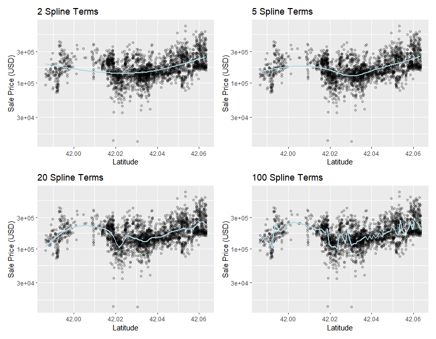

```r
library(patchwork)
library(splines)

plot_smoother <- function(deg_free) {
  ggplot(ames_train, aes(x = Latitude, y = 10^Sale_Price)) +
    geom_point(alpha = .2) +
    scale_y_log10() +
    geom_smooth(
      method = lm,
      formula = y ~ ns(x, df = deg_free),
      color = "lightblue",
      se = FALSE
    ) +
    labs(title = paste(deg_free, "Spline Terms"),
         y = "Sale Price (USD)")
}

( plot_smoother(2) + plot_smoother(5) ) / ( plot_smoother(20) + plot_smoother(100) )
```

```r
recipe(Sale_Price ~ Neighborhood + Gr_Liv_Area + Year_Built + Bldg_Type + Latitude,
         data = ames_train) %>%
  step_log(Gr_Liv_Area, base = 10) %>%
  step_other(Neighborhood, threshold = 0.01) %>%
  step_dummy(all_nominal_predictors()) %>%
  step_interact( ~ Gr_Liv_Area:starts_with("Bldg_Type_") ) %>%
  step_ns(Latitude, deg_free = 20)
```

```
## Recipe
##
## Inputs:
##
##       role #variables
##    outcome          1
##  predictor          5
##
## Operations:
##
## Log transformation on Gr_Liv_Area
## Collapsing factor levels for Neighborhood
## Dummy variables from all_nominal_predictors()
## Interactions with Gr_Liv_Area:starts_with("Bldg_Type_")
## Natural Splines on Latitude
```

```r
ames_rec <-
  recipe(Sale_Price ~ Neighborhood + Gr_Liv_Area + Year_Built + Bldg_Type +
           Latitude + Longitude, data = ames_train) %>%
  step_log(Gr_Liv_Area, base = 10) %>%
  step_other(Neighborhood, threshold = 0.01) %>%
  step_dummy(all_nominal_predictors()) %>%
  step_interact( ~ Gr_Liv_Area:starts_with("Bldg_Type_") ) %>%
  step_ns(Latitude, Longitude, deg_free = 20)
```

```r
tidy(ames_rec)
```

| number | operation | type | trained | skip | id |
| --- | --- | --- | --- | --- | --- |
| 1 | step | log | FALSE | FALSE | log_bDlz5 |
| 2 | step | other | FALSE | FALSE | other_WmExf |
| 3 | step | dummy | FALSE | FALSE | dummy_1MbxZ |
| 4 | step | interact | FALSE | FALSE | interact_UcdLo |
| 5 | step | ns | FALSE | FALSE | ns_zQ4Jj |

```r
ames_rec <-
  recipe(Sale_Price ~ Neighborhood + Gr_Liv_Area + Year_Built + Bldg_Type +
           Latitude + Longitude, data = ames_train) %>%
  step_log(Gr_Liv_Area, base = 10) %>%
  step_other(Neighborhood, threshold = 0.01, id = "my_id") %>%
  step_dummy(all_nominal_predictors()) %>%
  step_interact( ~ Gr_Liv_Area:starts_with("Bldg_Type_") ) %>%
  step_ns(Latitude, Longitude, deg_free = 20)
```

Volveremos a ajustar el flujo de trabajo con esta nueva receta:

```r
lm_wflow <-
  workflow() %>%
  add_model(lm_model) %>%
  add_recipe(ames_rec)

lm_fit <- fit(lm_wflow, ames_train)
```

El método se puede llamar de nuevo junto con el identificador que especificamos para obtener estos resultados:tidy()id

```r
estimated_recipe <-
  lm_fit %>%
  extract_recipe(estimated = TRUE)

tidy(estimated_recipe, id = "my_id")
```

| terms | retained | id |
| --- | --- | --- |
| Neighborhood | North_Ames | my_id |
| Neighborhood | College_Creek | my_id |
| Neighborhood | Old_Town | my_id |
| Neighborhood | Edwards | my_id |
| Neighborhood | Somerset | my_id |
| Neighborhood | Northridge_Heights | my_id |
| Neighborhood | Gilbert | my_id |
| Neighborhood | Sawyer | my_id |
| Neighborhood | Northwest_Ames | my_id |
| Neighborhood | Sawyer_West | my_id |

[output cut: 11 more lines]

```r
tidy(estimated_recipe, number = 2)
```

| terms | retained | id |
| --- | --- | --- |
| Neighborhood | North_Ames | my_id |
| Neighborhood | College_Creek | my_id |
| Neighborhood | Old_Town | my_id |
| Neighborhood | Edwards | my_id |
| Neighborhood | Somerset | my_id |
| Neighborhood | Northridge_Heights | my_id |
| Neighborhood | Gilbert | my_id |
| Neighborhood | Sawyer | my_id |
| Neighborhood | Northwest_Ames | my_id |
| Neighborhood | Sawyer_West | my_id |

[output cut: 11 more lines]

Cada método devuelve la información relevante sobre ese paso. Por ejemplo, el método para devuelve una columna con las variables que se convirtieron en variables ficticias y otra columna con todos los niveles conocidos para cada columna.tidy()tidy()step_dummy()

**resumen**

```r
library(tidymodels)
data(ames)
ames <- mutate(ames, Sale_Price = log10(Sale_Price))

set.seed(123)
ames_split <- initial_split(ames, prop = 0.80, strata = Sale_Price)
ames_train <- training(ames_split)
ames_test  <-  testing(ames_split)

ames_rec <-
  recipe(Sale_Price ~ Neighborhood + Gr_Liv_Area + Year_Built + Bldg_Type +
           Latitude + Longitude, data = ames_train) %>%
  step_log(Gr_Liv_Area, base = 10) %>%
  step_other(Neighborhood, threshold = 0.01) %>%
  step_dummy(all_nominal_predictors()) %>%
  step_interact( ~ Gr_Liv_Area:starts_with("Bldg_Type_") ) %>%
  step_ns(Latitude, Longitude, deg_free = 20)

lm_model <- linear_reg() %>% set_engine("lm")

lm_wflow <-
  workflow() %>%
  add_model(lm_model) %>%
  add_recipe(ames_rec)

lm_fit <- fit(lm_wflow, ames_train)

lm_fit
```

```
## == Workflow [trained] ==========================================================
## Preprocessor: Recipe
## Model: linear_reg()
##
## -- Preprocessor ----------------------------------------------------------------
## 5 Recipe Steps
##
## * step_log()
## * step_other()
## * step_dummy()
## * step_interact()
## * step_ns()
##
## -- Model -----------------------------------------------------------------------
##
## Call:
## stats::lm(formula = ..y ~ ., data = data)
##
## Coefficients:
##                                          (Intercept)
##                                           -0.2695536
##                                          Gr_Liv_Area
##                                            0.6304699
##                                           Year_Built
##                                            0.0018174
##                           Neighborhood_College_Creek
##                                           -0.0247388
##                                Neighborhood_Old_Town
##                                           -0.0661364
##                                 Neighborhood_Edwards
##                                           -0.1054911
##                                Neighborhood_Somerset
##                                            0.0693337
##                      Neighborhood_Northridge_Heights
##                                            0.1391016
##                                 Neighborhood_Gilbert
##                                            0.0215831
##                                  Neighborhood_Sawyer
##                                           -0.1177473
##                          Neighborhood_Northwest_Ames
```

[output cut: 12 more lines]

```
##                                            0.0049922
##                              Neighborhood_Northridge
##                                            0.0618041
##                             Neighborhood_Stone_Brook
##                                            0.2017678
## Neighborhood_South_and_West_of_Iowa_State_University
##                                           -0.0094936
##                             Neighborhood_Clear_Creek
##                                           -0.0537345
##                          Neighborhood_Meadow_Village
##                                           -0.1510563
##                               Neighborhood_Briardale
##
## ...
## and 100 more lines.
```

```r
ames_test_res <- predict(lm_fit, new_data = ames_test %>% select(-Sale_Price))
ames_test_res
```

| .pred |
| --- |
| 5.073059 |
| 5.174711 |
| 5.282365 |
| 5.048316 |
| 5.506291 |
| 5.418626 |
| 5.549593 |
| 5.327130 |
| 5.233546 |
| 5.533426 |

[output cut: 578 more lines]

El resultado numérico predicho a partir del modelo de regresión se denomina . Hagamos coincidir los valores predichos con sus correspondientes valores de resultado observados:.pred

```r
ames_test_res <- bind_cols(ames_test_res, ames_test %>% select(Sale_Price))
ames_test_res
```

| .pred | Sale_Price |
| --- | --- |
| 5.073059 | 5.021189 |
| 5.174711 | 5.235528 |
| 5.282365 | 5.278525 |
| 5.048316 | 5.060698 |
| 5.506291 | 5.596808 |
| 5.418626 | 5.330414 |
| 5.549593 | 5.786508 |
| 5.327130 | 5.244277 |
| 5.233546 | 5.265996 |
| 5.533426 | 5.522663 |

[output cut: 578 more lines]

resultados predichos como los observados están en unidades log10. Es una buena práctica analizar las predicciones en la escala transformada (si se utilizó una) incluso si las predicciones se informan utilizando las unidades originales.

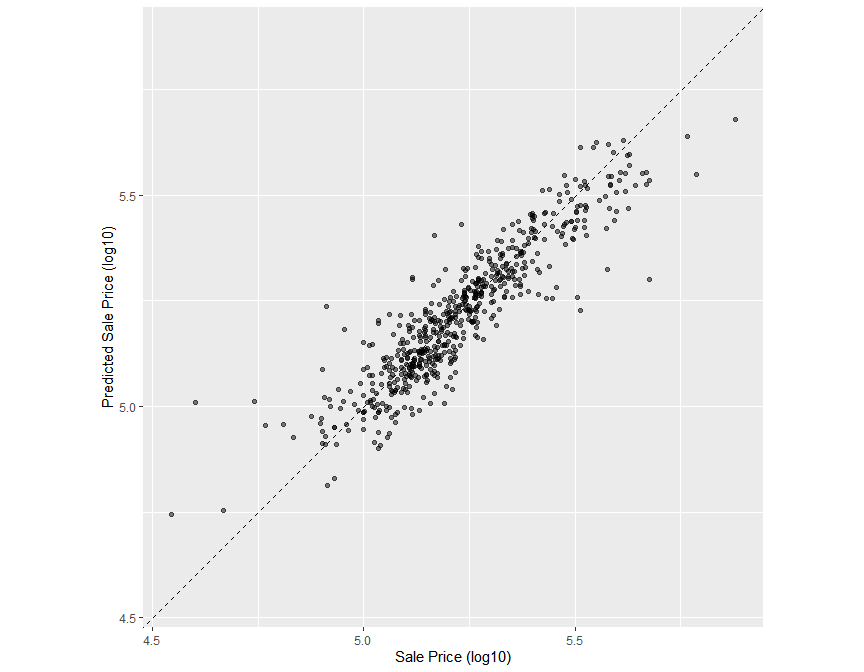

```r
ggplot(ames_test_res, aes(x = Sale_Price, y = .pred)) +
  # Create a diagonal line:
  geom_abline(lty = 2) +
  geom_point(alpha = 0.5) +
  labs(y = "Predicted Sale Price (log10)", x = "Sale Price (log10)") +
  # Scale and size the x- and y-axis uniformly:
  coord_obs_pred()
```

Calculemos el error cuadrático medio raíz para este modelo usando la función:rmse()

```r
rmse(ames_test_res, truth = Sale_Price, estimate = .pred)
```

| .metric | .estimator | .estimate |
| --- | --- | --- |
| rmse | standard | 0.07540111 |

La salida anterior muestra el formato estándar de la salida de las funciones de vara de medir. Las métricas para resultados numéricos generalmente tienen un valor de “estándar” para la columna. En las secciones siguientes se muestran ejemplos con valores diferentes para esta columna..estimator

```r
ames_metrics <- metric_set(rmse, rsq, mae)
ames_metrics(ames_test_res, truth = Sale_Price, estimate = .pred)
```

| .metric | .estimator | .estimate |
| --- | --- | --- |
| rmse | standard | 0.07540111 |
| rsq | standard | 0.82616339 |
| mae | standard | 0.05457768 |

Este formato de datos ordenado apila las métricas verticalmente.

Usando el mismo conjunto de predictores que el modelo lineal (sin los pasos adicionales de preprocesamiento), podemos ajustar un modelo de bosque aleatorio al conjunto de entrenamiento a través del paquete ranger. Este modelo no requiere preprocesamiento, por lo que se puede utilizar una fórmula simple

```r
# install.packages("ranger")
library(ranger)

rf_model <-
  rand_forest(trees = 1000) %>%
  set_engine("ranger") %>%
  set_mode("regression")

rf_wflow <-
  workflow() %>%
  add_formula(
    Sale_Price ~ Neighborhood + Gr_Liv_Area + Year_Built + Bldg_Type +
      Latitude + Longitude) %>%
  add_model(rf_model)

rf_fit <- rf_wflow %>% fit(data = ames_train)
```

¿Cómo se deben comparar los dos modelos? Para la demostración, predeciremos el conjunto de entrenamiento para producir lo que se conoce como la “tasa de error aparente” o la “tasa de error de resubstitución”. Esta función crea predicciones y da formato a los resultados:

```r
estimate_perf <- function(model, dat) {
  # Capture the names of the objects used
  cl <- match.call()
  obj_name <- as.character(cl$model)
  data_name <- as.character(cl$dat)
  data_name <- gsub("ames_", "", data_name)


  reg_metrics <- metric_set(rmse, rsq)

  model %>%
    predict(dat) %>%
    bind_cols(dat %>% select(Sale_Price)) %>%
    reg_metrics(Sale_Price, .pred) %>%
    select(-.estimator) %>%
    mutate(object = obj_name, data = data_name)
}
```

Tanto RMSE como R2 se computan. Las estadísticas de resubstitución son:

```r
estimate_perf(rf_fit, ames_train)
```

| .metric | .estimate | object | data |
| --- | --- | --- | --- |
| rmse | 0.03668451 | rf_fit | train |
| rsq | 0.96000599 | rf_fit | train |

```r
estimate_perf(lm_fit, ames_train)
```

| .metric | .estimate | object | data |
| --- | --- | --- | --- |
| rmse | 0.07507815 | lm_fit | train |
| rsq | 0.81882250 | lm_fit | train |

```r
estimate_perf(rf_fit, ames_test)
```

| .metric | .estimate | object | data |
| --- | --- | --- | --- |
| rmse | 0.06942434 | rf_fit | test |
| rsq | 0.85324350 | rf_fit | test |

Muchos modelos predictivos son capaces de aprender tendencias complejas a partir de los datos. En estadística, estos se conocen comúnmente como modelos de bajo sesgo. Para un modelo de bajo sesgo, el alto grado de capacidad predictiva a veces puede resultar en que el modelo casi memorice los datos del conjunto de entrenamiento. Como ejemplo obvio, considere un modelo de vecino 1 más cercano. Siempre proporcionará predicciones perfectas para el conjunto de entrenamiento, sin importar qué tan bien funcione realmente para otros conjuntos de datos. Los modelos de bosque aleatorio son similares; volver a predecir el conjunto de entrenamiento siempre resultará en una estimación artificialmente optimista del rendimiento.

el modelo de regresión lineal es consistente entre el entrenamiento y las pruebas, debido a su complejidad limitada.

Si el conjunto de pruebas no debe usarse de inmediato, y volver a predecir el conjunto de entrenamiento es una mala idea, ¿qué se debe hacer? Los métodos de remuestreo, como la validación cruzada o los conjuntos de validación, son la solución.

**MÉTODOS DE REMUESTREO**

VALIDACION CRUZADA

```r
set.seed(55)
ames_folds <- vfold_cv(ames_train, v = 10)
ames_folds
```

| splits | id |
| --- | --- |
|  | Fold01 |
|  | Fold02 |
|  | Fold03 |
|  | Fold04 |
|  | Fold05 |
|  | Fold06 |
|  | Fold07 |
|  | Fold08 |
|  | Fold09 |
|  | Fold10 |

Para recuperar manualmente los datos particionados, las funciones y devuelven los marcos de datos correspondientes:analysis()assessment()

```r
# For the first fold:
ames_folds$splits[[1]] %>% analysis() %>% dim()
```

```
## [1] 2107   74
```

VALIDACIÓN CRUZADA REPETIDA

```r
vfold_cv(ames_train, v = 10, repeats = 5)
```

| splits | id | id2 |
| --- | --- | --- |
|  | Repeat1 | Fold01 |
|  | Repeat1 | Fold02 |
|  | Repeat1 | Fold03 |
|  | Repeat1 | Fold04 |
|  | Repeat1 | Fold05 |
|  | Repeat1 | Fold06 |
|  | Repeat1 | Fold07 |
|  | Repeat1 | Fold08 |
|  | Repeat1 | Fold09 |
|  | Repeat1 | Fold10 |

[output cut: 40 more lines]

VALIDACIÓN CRUZADA LEAVE-ONE-OUT:

Una variación temprana de la validación cruzada fue la validación cruzada leave-one-out (LOO) donde V es el número de puntos de datos en el conjunto de entrenamiento. Si hay $n$ ejemplos de conjunto de entrenamiento, $n$ los modelos se ajustan utilizando $n-1$ filas del conjunto de entrenamiento. Cada modelo predice el único punto de datos excluido. Al final del remuestreo, las predicciones $n$ se agrupan para producir una única estadística de rendimiento.

Los métodos de dejar uno fuera son deficientes en comparación con casi cualquier otro método. Para cualquier cosa que no sean muestras patológicamente pequeñas, LOO es computacionalmente excesivo y puede no tener buenas propiedades estadísticas. Aunque rsample contiene una función, estos objetos generalmente no están integrados en los marcos más amplios de tidymodels.loo_cv()

VALIDACIÓN CRUZADA MONTE CARLO

Finalmente, otra variante de la validación cruzada en V es la validación cruzada monte carlo (MCCV, Xu y Liang (2001)). Al igual que la validación cruzada V-fold, asigna una proporción fija de datos a los conjuntos de evaluación. La diferencia es que, para MCCV, esta proporción de los datos se selecciona aleatoriamente cada vez. Esto da como resultado conjuntos de evaluación que no son mutuamente excluyentes. Para crear estos objetos de remuestreo:

```r
mc_cv(ames_train, prop = 9/10, times = 20)
```

| splits | id |
| --- | --- |
|  | Resample01 |
|  | Resample02 |
|  | Resample03 |
|  | Resample04 |
|  | Resample05 |
|  | Resample06 |
|  | Resample07 |
|  | Resample08 |
|  | Resample09 |
|  | Resample10 |

[output cut: 10 more lines]

CONJUNTOS DE VALIDACIÓN Para crear un objeto de conjunto de validación que utilice 3/4 de los datos para la conexión del modelo:

```r
set.seed(12)
val_set <- validation_split(ames_train, prop = 3/4)
val_set
```

| splits | id |
| --- | --- |
|  | validation |

BOOTSTRAPPING

El remuestreo Bootstrap se inventó originalmente como un método para aproximar la distribución de muestreo de estadísticas cuyas propiedades teóricas son intratables (Davison y Hinkley 1997). Usarlo para estimar el rendimiento del modelo es una aplicación secundaria del método.

Una muestra de bootstrap del conjunto de entrenamiento es una muestra que tiene el mismo tamaño que el conjunto de entrenamiento, pero se extrae con reemplazo. Esto significa que algunos puntos de datos del conjunto de entrenamiento se seleccionan varias veces para el conjunto de análisis. Cada punto de datos tiene una probabilidad del 63,2% de inclusión en el conjunto de entrenamiento al menos una vez. El conjunto de evaluación contiene todas las muestras del conjunto de entrenamiento que no fueron seleccionadas para el conjunto de análisis (en promedio, con el 36,8% del conjunto de entrenamiento). Al arrancar, el conjunto de evaluación a menudo se denomina muestra “fuera de bolsa”. usando rsample:

```r
bootstraps(ames_train, times = 5)
```

| splits | id |
| --- | --- |
|  | Bootstrap1 |
|  | Bootstrap2 |
|  | Bootstrap3 |
|  | Bootstrap4 |
|  | Bootstrap5 |

Las muestras de Bootstrap producen estimaciones de rendimiento que tienen una varianza muy baja (a diferencia de la validación cruzada) pero tienen un sesgo pesimista significativo. Esto significa que, si la verdadera precisión de un modelo es del 90%, el bootstrap tendería a estimar que el valor es inferior al 90%. La cantidad de sesgo no se puede determinar empíricamente con suficiente precisión. Además, la cantidad de sesgo cambia sobre la escala de la métrica de rendimiento. Por ejemplo, es probable que el sesgo sea diferente cuando la precisión es del 90% frente a cuando es del 70%.

REMUESTREO DE ORIGEN DE LA PREVISIÓN CONTINUA

```r
time_slices <-
  tibble(x = 1:365) %>%
  rolling_origin(initial = 6 * 30, assess = 30, skip = 29, cumulative = FALSE)

data_range <- function(x) {
  summarize(x, first = min(x), last = max(x))
}

map_dfr(time_slices$splits, ~   analysis(.x) %>% data_range())
```

| first | last |
| --- | --- |
| 1 | 180 |
| 31 | 210 |
| 61 | 240 |
| 91 | 270 |
| 121 | 300 |
| 151 | 330 |

```r
map_dfr(time_slices$splits, ~ assessment(.x) %>% data_range())
```

| first | last |
| --- | --- |
| 181 | 210 |
| 211 | 240 |
| 241 | 270 |
| 271 | 300 |
| 301 | 330 |
| 331 | 360 |

Hay una serie de otros argumentos opcionales, tales como:

metrics: Un conjunto métrico de estadísticas de rendimiento para calcular. De forma predeterminada, los modelos de regresión utilizan RMSE y R2 mientras que los modelos de clasificación calculan el área bajo la curva ROC y la precisión general. Tenga en cuenta que esta elección también define qué predicciones se producen durante la evaluación del modelo. Para la clasificación, si solo se solicita precisión, no se generan estimaciones de probabilidad de clase para el conjunto de evaluación (ya que no son necesarias).

control: Una lista creada por con varias opciones.control_resamples()

Los argumentos de control incluyen:

verbose: Un lógico para el registro de impresión.

extract: Una función para retener objetos de cada iteración del modelo (que se analiza a continuación).

save_pred: Un lógico para guardar las predicciones del conjunto de evaluación

```r
keep_pred <- control_resamples(save_pred = TRUE, save_workflow = TRUE)

set.seed(130)
rf_res <-
  rf_wflow %>%
  fit_resamples(resamples = ames_folds, control = keep_pred)
rf_res
```

| splits | id | .metrics | .notes | .predictions |
| --- | --- | --- | --- | --- |
|  | Fold01 |  |  |  |
|  | Fold02 |  |  |  |
|  | Fold03 |  |  |  |
|  | Fold04 |  |  |  |
|  | Fold05 |  |  |  |
|  | Fold06 |  |  |  |
|  | Fold07 |  |  |  |
|  | Fold08 |  |  |  |
|  | Fold09 |  |  |  |
|  | Fold10 |  |  |  |

El valor devuelto es un tibble similar a las muestras de entrada, junto con algunas columnas adicionales:

.metrics es una columna de lista de tibbles que contiene las estadísticas de rendimiento del conjunto de evaluación.

.notes es otra columna de lista de tibbles catalogando cualquier advertencia o error generado durante el remuestreo. Tenga en cuenta que los errores no detendrán la ejecución posterior del remuestreo.

.predictions está presente cuando . Esta columna de lista contiene tibbles con las predicciones fuera de muestra.save_pred = TRUE

Si bien estas columnas de lista pueden parecer desalentadoras, se pueden reconfigurar fácilmente utilizando tidyr o con funciones de conveniencia que proporciona tidymodels. Por ejemplo, para devolver las métricas de rendimiento en un formato más utilizable:

```r
collect_metrics(rf_res)
```

| .metric | .estimator | mean | n | std_err | .config |
| --- | --- | --- | --- | --- | --- |
| rmse | standard | 0.07213549 | 10 | 0.002442919 | Preprocessor1_Model1 |
| rsq | standard | 0.83391152 | 10 | 0.007483214 | Preprocessor1_Model1 |

Estas son las estimaciones de remuestreo promediadas sobre las réplicas individuales. Para obtener las métricas de cada nueva muestra, utilice la opción summarize = FALSE

Para obtener las predicciones del conjunto de evaluación:

```r
assess_res <- collect_predictions(rf_res)
assess_res
```

| id | .pred | .row | Sale_Price | .config |
| --- | --- | --- | --- | --- |
| Fold01 | 5.143279 | 12 | 5.110421 | Preprocessor1_Model1 |
| Fold01 | 5.146596 | 49 | 5.103804 | Preprocessor1_Model1 |
| Fold01 | 4.957504 | 54 | 4.928908 | Preprocessor1_Model1 |
| Fold01 | 5.034336 | 84 | 5.049218 | Preprocessor1_Model1 |
| Fold01 | 5.187674 | 99 | 5.053078 | Preprocessor1_Model1 |
| Fold01 | 5.108484 | 116 | 4.977724 | Preprocessor1_Model1 |
| Fold01 | 4.968649 | 120 | 4.968016 | Preprocessor1_Model1 |
| Fold01 | 5.124716 | 122 | 5.107210 | Preprocessor1_Model1 |
| Fold01 | 5.088780 | 124 | 5.039414 | Preprocessor1_Model1 |
| Fold01 | 4.979025 | 140 | 4.960471 | Preprocessor1_Model1 |

[output cut: 2332 more lines]

Los nombres de las columnas de predicción siguen las convenciones discutidas para los modelos. La columna de resultados observados siempre utiliza el nombre de columna original de los datos de origen. La columna es un entero que coincide con la fila del conjunto de entrenamiento original para que estos resultados se puedan organizar y unir correctamente con los datos originales..row

Dado que este análisis utilizó la validación cruzada 10 veces mayor, hay una predicción única para cada muestra del conjunto de entrenamiento. Estos datos pueden generar gráficos útiles del modelo para comprender dónde falló potencialmente.

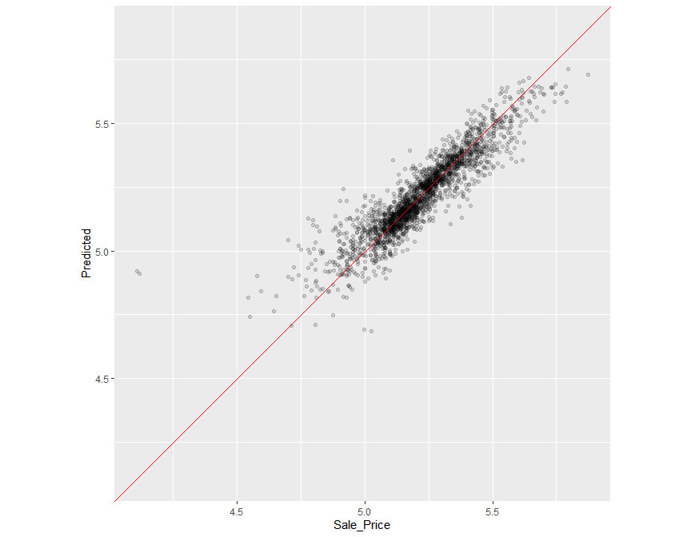

```r
assess_res %>%
  ggplot(aes(x = Sale_Price, y = .pred)) +
  geom_point(alpha = .15) +
  geom_abline(color = "red") +
  coord_obs_pred() +
  ylab("Predicted")
```

Había una casa en el conjunto de entrenamiento con un bajo precio de venta observado que es significativamente sobrepredido por el modelo. ¿Qué casa era esa?

```r
over_predicted <-
  assess_res %>%
  mutate(residual = Sale_Price - .pred) %>%
  arrange(desc(abs(residual))) %>%
  slice(1)
over_predicted
```

| id | .pred | .row | Sale_Price | .config | residual |
| --- | --- | --- | --- | --- | --- |
| Fold07 | 4.92059 | 32 | 4.106837 | Preprocessor1_Model1 | -0.8137532 |

```r
ames_train %>%
  slice(over_predicted$.row) %>%
  select(Gr_Liv_Area, Neighborhood, Year_Built, Bedroom_AbvGr, Full_Bath)
```

| Gr_Liv_Area | Neighborhood | Year_Built | Bedroom_AbvGr | Full_Bath |
| --- | --- | --- | --- | --- |
| 832 | Old_Town | 1923 | 2 | 1 |

Estos resultados pueden ayudarnos a investigar por qué la predicción fue pobre para esta casa.

¿Cómo podemos usar un conjunto de validación en lugar de una validación cruzada? De nuestro objeto rsample anterior

```r
val_res <- rf_wflow %>% fit_resamples(resamples = val_set)
val_res
```

| splits | id | .metrics | .notes |
| --- | --- | --- | --- |
|  | validation |  |  |

```r
collect_metrics(val_res)
```

| .metric | .estimator | mean | n | std_err | .config |
| --- | --- | --- | --- | --- | --- |
| rmse | standard | 0.07779127 | 1 | NA | Preprocessor1_Model1 |
| rsq | standard | 0.81417278 | 1 | NA | Preprocessor1_Model1 |

**GUARDAR LOS OBJETOS REMUESTREADOS**

Ajustemos un modelo de regresión lineal

```r
ames_rec <-
  recipe(Sale_Price ~ Neighborhood + Gr_Liv_Area + Year_Built + Bldg_Type +
           Latitude + Longitude, data = ames_train) %>%
  step_other(Neighborhood, threshold = 0.01) %>%
  step_dummy(all_nominal_predictors()) %>%
  step_interact( ~ Gr_Liv_Area:starts_with("Bldg_Type_") ) %>%
  step_ns(Latitude, Longitude, deg_free = 20)

lm_wflow <-
  workflow() %>%
  add_recipe(ames_rec) %>%
  add_model(linear_reg() %>% set_engine("lm"))

lm_fit <- lm_wflow %>% fit(data = ames_train)


extract_recipe(lm_fit, estimated = TRUE)
```

```
## Recipe
##
## Inputs:
##
##       role #variables
##    outcome          1
##  predictor          6
##
## Training data contained 2342 data points and no missing data.
##
## Operations:
##
## Collapsing factor levels for Neighborhood [trained]
## Dummy variables from Neighborhood, Bldg_Type [trained]
## Interactions with Gr_Liv_Area:(Bldg_Type_TwoFmCon + Bldg_Type_Duplex + Bldg_Type_Twnhs + Bldg_Type_TwnhsE) [trained]
## Natural Splines on Latitude, Longitude [trained]
```

Podemos guardar los coeficientes del modelo lineal para un objeto de modelo ajustado desde un flujo de trabajo:

```r
get_model <- function(x) {
  extract_fit_parsnip(x) %>% tidy()
}

# get_model(lm_fit)
```

Ahora apliquemos esta función a los diez ajustes remuestreados. Los resultados de la función de extracción se envuelven en un objeto list y se devuelven en un tibble:

```r
ctrl <- control_resamples(extract = get_model)

lm_res <- lm_wflow %>%  fit_resamples(resamples = ames_folds, control = ctrl)
lm_res
```

| splits | id | .metrics | .notes | .extracts |
| --- | --- | --- | --- | --- |
|  | Fold01 |  |  |  |
|  | Fold02 |  |  |  |
|  | Fold03 |  |  |  |
|  | Fold04 |  |  |  |
|  | Fold05 |  |  |  |
|  | Fold06 |  |  |  |
|  | Fold07 |  |  |  |
|  | Fold08 |  |  |  |
|  | Fold09 |  |  |  |
|  | Fold10 |  |  |  |

Ahora hay una columna con tibbles anidados. ¿Qué contienen?.extracts

```r
lm_res$.extracts[[1]]
```

| .extracts | .config |
| --- | --- |
|  | Preprocessor1_Model1 |

```r
lm_res$.extracts[[1]][[1]]
```

```
## [[1]]
## # A tibble: 73 x 5
##    term                             estimate  std.error statistic   p.value
##    <chr>                               <dbl>      <dbl>     <dbl>     <dbl>
##  1 (Intercept)                      1.29     0.323         3.99   6.86e-  5
##  2 Gr_Liv_Area                      0.000159 0.00000464   34.4    1.19e-204
##  3 Year_Built                       0.00188  0.000148     12.7    1.25e- 35
##  4 Neighborhood_College_Creek      -0.00264  0.0375       -0.0706 9.44e-  1
##  5 Neighborhood_Old_Town           -0.0834   0.0143       -5.85   5.86e-  9
##  6 Neighborhood_Edwards            -0.108    0.0311       -3.48   5.04e-  4
##  7 Neighborhood_Somerset            0.0857   0.0206        4.17   3.19e-  5
##  8 Neighborhood_Northridge_Heights  0.155    0.0373        4.16   3.38e-  5
##  9 Neighborhood_Gilbert             0.0334   0.0335        0.997  3.19e-  1
## 10 Neighborhood_Sawyer             -0.117    0.0296       -3.94   8.32e-  5
## # ... with 63 more rows
```

Esto puede parecer un método complicado para guardar los resultados del modelo. Sin embargo, es flexible y no asume que el usuario solo guardará un solo tibble por remuestreo. Por ejemplo, el método podría ejecutarse en la receta y en el modelo. En este caso, se devolverá una lista de dos tibbles.extracttidy()

```r
all_coef <- map_dfr(lm_res$.extracts, ~ .x[[1]][[1]])

filter(all_coef, term == "Year_Built")
```

| term | estimate | std.error | statistic | p.value |
| --- | --- | --- | --- | --- |
| Year_Built | 0.001881924 | 0.0001481548 | 12.70242 | 1.245200e-35 |
| Year_Built | 0.001841789 | 0.0001492130 | 12.34335 | 8.299885e-34 |
| Year_Built | 0.001848377 | 0.0001474098 | 12.53904 | 8.516310e-35 |
| Year_Built | 0.001921165 | 0.0001531619 | 12.54336 | 8.084274e-35 |
| Year_Built | 0.001829713 | 0.0001469546 | 12.45088 | 2.381181e-34 |
| Year_Built | 0.001940067 | 0.0001475139 | 13.15175 | 5.609984e-38 |
| Year_Built | 0.001851668 | 0.0001426868 | 12.97715 | 4.658629e-37 |
| Year_Built | 0.001793843 | 0.0001475710 | 12.15579 | 7.143862e-33 |
| Year_Built | 0.001926331 | 0.0001417159 | 13.59291 | 2.403247e-40 |
| Year_Built | 0.001773945 | 0.0001423004 | 12.46620 | 1.991905e-34 |

**resumen**

```r
library(tidymodels)
data(ames)
ames <- mutate(ames, Sale_Price = log10(Sale_Price))

set.seed(123)
ames_split <- initial_split(ames, prop = 0.80, strata = Sale_Price)
ames_train <- training(ames_split)
ames_test  <-  testing(ames_split)

ames_rec <-
  recipe(Sale_Price ~ Neighborhood + Gr_Liv_Area + Year_Built + Bldg_Type +
           Latitude + Longitude, data = ames_train) %>%
  step_log(Gr_Liv_Area, base = 10) %>%
  step_other(Neighborhood, threshold = 0.01) %>%
  step_dummy(all_nominal_predictors()) %>%
  step_interact( ~ Gr_Liv_Area:starts_with("Bldg_Type_") ) %>%
  step_ns(Latitude, Longitude, deg_free = 20)

lm_model <- linear_reg() %>% set_engine("lm")

lm_wflow <-
  workflow() %>%
  add_model(lm_model) %>%
  add_recipe(ames_rec)

lm_fit <- fit(lm_wflow, ames_train)

rf_model <-
  rand_forest(trees = 1000) %>%
  set_engine("ranger") %>%
  set_mode("regression")

rf_wflow <-
  workflow() %>%
  add_formula(
    Sale_Price ~ Neighborhood + Gr_Liv_Area + Year_Built + Bldg_Type +
      Latitude + Longitude) %>%
  add_model(rf_model)

set.seed(55)
ames_folds <- vfold_cv(ames_train, v = 10)

keep_pred <- control_resamples(save_pred = TRUE, save_workflow = TRUE)

set.seed(130)
rf_res <- rf_wflow %>% fit_resamples(resamples = ames_folds, control = keep_pred)
```

**Comparación de modelos**

```r
library(tidymodels)
tidymodels_prefer()

basic_rec <-
  recipe(Sale_Price ~ Neighborhood + Gr_Liv_Area + Year_Built + Bldg_Type +
           Latitude + Longitude, data = ames_train) %>%
  step_log(Gr_Liv_Area, base = 10) %>%
  step_other(Neighborhood, threshold = 0.01) %>%
  step_dummy(all_nominal_predictors())

interaction_rec <-
  basic_rec %>%
  step_interact( ~ Gr_Liv_Area:starts_with("Bldg_Type_") )

spline_rec <-
  interaction_rec %>%
  step_ns(Latitude, Longitude, deg_free = 50)

preproc <-
  list(basic = basic_rec,
       interact = interaction_rec,
       splines = spline_rec
  )

lm_models <- workflow_set(preproc, list(lm = lm_model), cross = FALSE)
lm_models
```

| wflow_id | info | option | result |
| --- | --- | --- | --- |
| basic_lm |  |  |  |
| interact_lm |  |  |  |
| splines_lm |  |  |  |

Nos gustaría volver a muestrear cada uno de estos modelos a su vez. Para hacerlo, se utiliza una función similar a purrr llamada. Esta función toma un argumento inicial de la función para aplicarlo a los flujos de trabajo, seguido de una opción para esa función. También establecemos un argumento que imprimirá el progreso, así como un argumento que se asegura de que cada modelo use el mismo flujo de números aleatorios que los demás.workflow_map()verboseseed

```r
lm_models <-
  lm_models %>%
  workflow_map("fit_resamples",
               # Options to `workflow_map()`:
               seed = 1101, verbose = TRUE,
               # Options to `fit_resamples()`:
               resamples = ames_folds, control = keep_pred)
```

```
## i 1 of 3 resampling: basic_lm
```

```
## v 1 of 3 resampling: basic_lm (7.2s)
```

```
## i 2 of 3 resampling: interact_lm
```

```
## v 2 of 3 resampling: interact_lm (7.5s)
```

```
## i 3 of 3 resampling: splines_lm
```

```
## v 3 of 3 resampling: splines_lm (8.7s)
```

```r
lm_models
```

| wflow_id | info | option | result |
| --- | --- | --- | --- |
| basic_lm |  |  |  |
| interact_lm |  |  |  |
| splines_lm |  |  |  |

Hay pocas funciones de conveniencia para los conjuntos de flujo de trabajo, incluida una para recopilar las estadísticas de rendimiento:

```r
collect_metrics(lm_models) %>%
  filter(.metric == "rmse")
```

| wflow_id | .config | preproc | model | .metric | .estimator | mean | n | std_err |
| --- | --- | --- | --- | --- | --- | --- | --- | --- |
| basic_lm | Preprocessor1_Model1 | recipe | linear_reg | rmse | standard | 0.07985567 | 10 | 0.002366160 |
| interact_lm | Preprocessor1_Model1 | recipe | linear_reg | rmse | standard | 0.07935361 | 10 | 0.002572961 |
| splines_lm | Preprocessor1_Model1 | recipe | linear_reg | rmse | standard | 0.07825221 | 10 | 0.002571658 |

¿Qué pasa con el modelo de bosque aleatorio del capítulo anterior? Podemos agregarlo al conjunto convirtiéndolo primero a su propio conjunto de flujo de trabajo y luego enlazando filas. Esto requiere que, cuando se volvió a muestrear el modelo, la opción se estableció en la función de control.save_workflow = TRUE

```r
four_models <-
  as_workflow_set(random_forest = rf_res) %>%
  bind_rows(lm_models)
four_models
```

| wflow_id | info | option | result |
| --- | --- | --- | --- |
| random_forest |  |  |  |
| basic_lm |  |  |  |
| interact_lm |  |  |  |
| splines_lm |  |  |  |

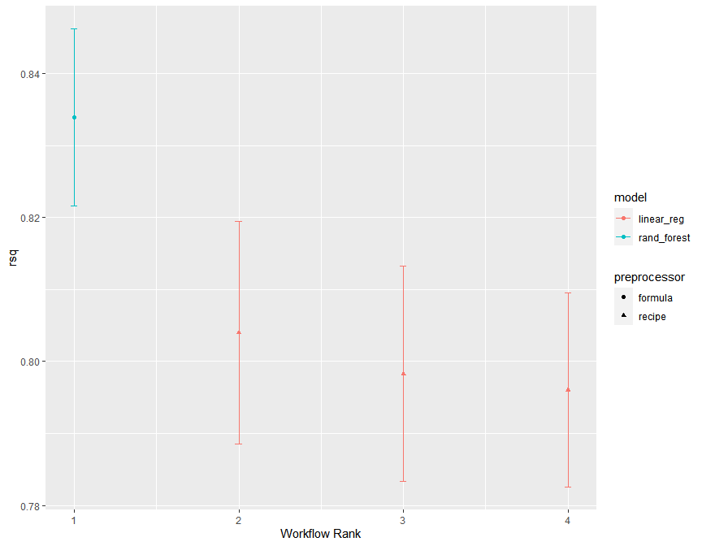

```r
autoplot(four_models, metric = "rsq")
```

El método de bosque aleatorio está haciendo el mejor trabajo y hay mejoras menores en los modelos lineales a medida que agregamos más pasos de la receta.

Ahora que tenemos 10 estimaciones de rendimiento remuestreadas para cada uno de los cuatro modelos, estas estadísticas resumidas se pueden usar para hacer comparaciones entre modelos

```r
rsq_indiv_estimates <-
  collect_metrics(four_models, summarize = FALSE) %>%
  filter(.metric == "rsq")

rsq_wider <-
  rsq_indiv_estimates %>%
  select(wflow_id, .estimate, id) %>%
  pivot_wider(id_cols = "id", names_from = "wflow_id", values_from = ".estimate")

corrr::correlate(rsq_wider %>% select(-id), quiet = TRUE)
```

| term | random_forest | basic_lm | interact_lm | splines_lm |
| --- | --- | --- | --- | --- |
| random_forest | NA | 0.8539805 | 0.7947916 | 0.8182427 |
| basic_lm | 0.8539805 | NA | 0.9907833 | 0.9761968 |
| interact_lm | 0.7947916 | 0.9907833 | NA | 0.9773423 |
| splines_lm | 0.8182427 | 0.9761968 | 0.9773423 | NA |

Estas altas correlaciones indican que, a través de los modelos, hay grandes correlaciones dentro de la muestra.

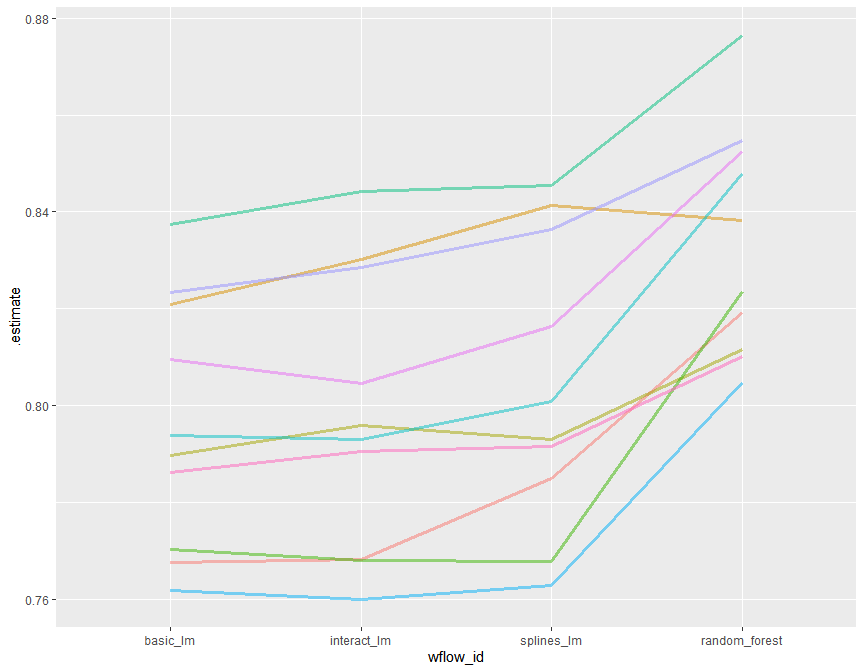

```r
rsq_indiv_estimates %>%
  mutate(wflow_id = reorder(wflow_id, .estimate)) %>%
  ggplot(aes(x = wflow_id, y = .estimate, group = id, color = id)) +
  geom_line(alpha = .5, lwd = 1.25) +
  theme(legend.position = "none")
```

Si el efecto de remuestreo a muestra no fuera real, no habría líneas paralelas. Una prueba estadística para las correlaciones evalúa si las magnitudes de estas correlaciones no son simplemente ruido. Para los modelos lineales:

```r
rsq_wider %>%
  with( cor.test(basic_lm, splines_lm) ) %>%
  tidy() %>%
  select(estimate, starts_with("conf"))
```

| estimate | conf.low | conf.high |
| --- | --- | --- |
| 0.9761968 | 0.8993404 | 0.9945399 |

La correlación dentro de la muestra parece ser real.

¿Qué efecto tiene la correlación adicional en nuestro análisis? Considere la varianza de una diferencia de dos variables:

$$var[x - y] = var[x] + var[y] - 2 cov[x, y]$$

Este modelo versátil se utiliza para crear modelos de regresión, además de ser la base para la técnica popular de análisis de varianza (ANOVA) para comparar grupos. Con el modelo ANOVA, los predictores ($x_{ij}$) son variables ficticias binarias para diferentes grupos. A partir de esto, los parámetros $\beta$ estiman si dos o más grupos son diferentes entre sí utilizando técnicas de prueba de hipótesis.

dónde

$\beta_0$ es la estimación de la media R2 estadística para los modelos lineales básicos (es decir, sin splines o interacciones),

$\beta_1$ es el cambio en la media R2 cuando se agregan interacciones al modelo lineal básico,

$\beta_2$ es el cambio en la media R2 entre el modelo lineal básico y el modelo de bosque aleatorio.

$\beta_3$ es el cambio en la media R2 entre el modelo lineal básico y uno con interacciones y splines.

```r
compare_lm <-
  rsq_wider %>%
  mutate(difference = splines_lm - basic_lm)

lm(difference ~ 1, data = compare_lm) %>%
  tidy(conf.int = TRUE) %>%
  select(estimate, p.value, starts_with("conf"))
```

| estimate | p.value | conf.low | conf.high |
| --- | --- | --- | --- |
| 0.007972592 | 0.006596143 | 0.002837509 | 0.01310767 |

```r
# Alternatively, a paired t-test could also be used:
rsq_wider %>%
  with( t.test(splines_lm, basic_lm, paired = TRUE) ) %>%
  tidy() %>%
  select(estimate, p.value, starts_with("conf"))
```

| estimate | p.value | conf.low | conf.high |
| --- | --- | --- | --- |
| 0.007972592 | 0.006596143 | 0.002837509 | 0.01310767 |

Podríamos evaluar cada diferencia por pares de esta manera. Nótese que el valor p indica una señal estadísticamente significativa; la colección de términos spline para longitud y latitud parece tener un efecto. Sin embargo, la diferencia en R2 se estima en un 0,8%. Si nuestro tamaño de efecto práctico fuera del 2%, podríamos no considerar que valga la pena incluir estos términos en el modelo.

**USO DEL RESULTADO PARA CODIFICAR PREDICTORES**

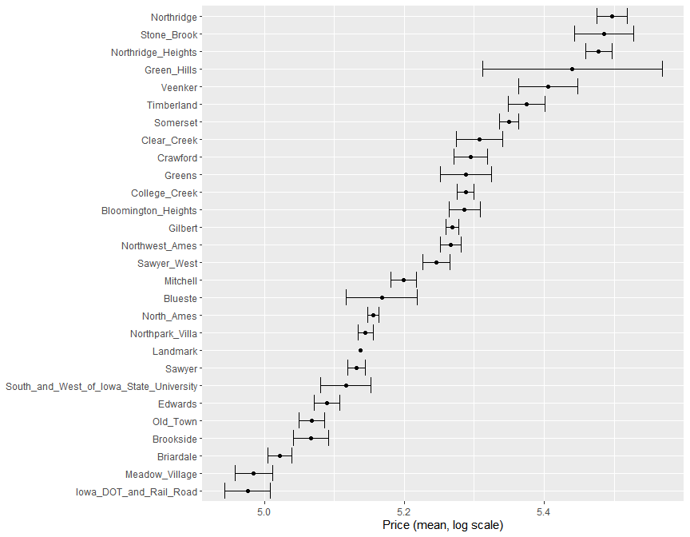

```r
ames_train %>%
  group_by(Neighborhood) %>%
  summarize(mean = mean(Sale_Price),
            std_err = sd(Sale_Price) / sqrt(length(Sale_Price))) %>%
  ggplot(aes(y = reorder(Neighborhood, mean), x = mean)) +
  geom_point() +
  geom_errorbar(aes(xmin = mean - 1.64 * std_err, xmax = mean + 1.64 * std_err)) +
  labs(y = NULL, x = "Price (mean, log scale)")
```

```r
library(embed)

ames_glm <-
  recipe(Sale_Price ~ Neighborhood + Gr_Liv_Area + Year_Built + Bldg_Type +
           Latitude + Longitude, data = ames_train) %>%
  step_log(Gr_Liv_Area, base = 10) %>%
  step_lencode_glm(Neighborhood, outcome = vars(Sale_Price)) %>%
  step_dummy(all_nominal_predictors()) %>%
  step_interact( ~ Gr_Liv_Area:starts_with("Bldg_Type_") ) %>%
  step_ns(Latitude, Longitude, deg_free = 20)

ames_glm
```

```
## Recipe
##
## Inputs:
##
##       role #variables
##    outcome          1
##  predictor          6
##
## Operations:
##
## Log transformation on Gr_Liv_Area
## Linear embedding for factors via GLM for Neighborhood
## Dummy variables from all_nominal_predictors()
## Interactions with Gr_Liv_Area:starts_with("Bldg_Type_")
## Natural Splines on Latitude, Longitude
```

```r
glm_estimates <-
  prep(ames_glm) %>%
  tidy(number = 2)

glm_estimates
```

| level | value | terms | id |
| --- | --- | --- | --- |
| North_Ames | 5.155374 | Neighborhood | lencode_glm_qvQK9 |
| College_Creek | 5.287539 | Neighborhood | lencode_glm_qvQK9 |
| Old_Town | 5.067438 | Neighborhood | lencode_glm_qvQK9 |
| Edwards | 5.089371 | Neighborhood | lencode_glm_qvQK9 |
| Somerset | 5.349542 | Neighborhood | lencode_glm_qvQK9 |
| Northridge_Heights | 5.477918 | Neighborhood | lencode_glm_qvQK9 |
| Gilbert | 5.268506 | Neighborhood | lencode_glm_qvQK9 |
| Sawyer | 5.131331 | Neighborhood | lencode_glm_qvQK9 |
| Northwest_Ames | 5.266265 | Neighborhood | lencode_glm_qvQK9 |
| Sawyer_West | 5.245754 | Neighborhood | lencode_glm_qvQK9 |

[output cut: 19 more lines]

Cuando usamos la variable numérica recién codificada creada a través de este método, sustituimos el nivel original (como ) con la estimación para el GLM.Neighborhood“North_Ames”Sale_Price

Los métodos de codificación de efectos como este también pueden manejar sin problemas situaciones en las que se encuentra un nuevo nivel de factor en los datos.

```r
glm_estimates %>%
  filter(level == "..new")
```

| level | value | terms | id |
| --- | --- | --- | --- |
| ..new | 5.232859 | Neighborhood | lencode_glm_qvQK9 |

Este es el precio previsto del GLM cuando no tenemos ninguna información específica del vecindario.

**CODIFICACIONES DE EFECTOS CON AGRUPACIÓN PARCIAL**

```r
ames_mixed <-
  recipe(Sale_Price ~ Neighborhood + Gr_Liv_Area + Year_Built + Bldg_Type +
           Latitude + Longitude, data = ames_train) %>%
  step_log(Gr_Liv_Area, base = 10) %>%
  step_lencode_mixed(Neighborhood, outcome = vars(Sale_Price)) %>%
  step_dummy(all_nominal_predictors()) %>%
  step_interact( ~ Gr_Liv_Area:starts_with("Bldg_Type_") ) %>%
  step_ns(Latitude, Longitude, deg_free = 20)

ames_mixed
```

```
## Recipe
##
## Inputs:
##
##       role #variables
##    outcome          1
##  predictor          6
##
## Operations:
##
## Log transformation on Gr_Liv_Area
## Linear embedding for factors via mixed effects for Neighborhood
## Dummy variables from all_nominal_predictors()
## Interactions with Gr_Liv_Area:starts_with("Bldg_Type_")
## Natural Splines on Latitude, Longitude
```

Vamos y esta receta para ver los resultados.prep()tidy()

```r
mixed_estimates <-
  prep(ames_mixed) %>%
  tidy(number = 2)

mixed_estimates
```

| level | value | terms | id |
| --- | --- | --- | --- |
| North_Ames | 5.155500 | Neighborhood | lencode_mixed_nSXq6 |
| College_Creek | 5.287390 | Neighborhood | lencode_mixed_nSXq6 |
| Old_Town | 5.067981 | Neighborhood | lencode_mixed_nSXq6 |
| Edwards | 5.089908 | Neighborhood | lencode_mixed_nSXq6 |
| Somerset | 5.349080 | Neighborhood | lencode_mixed_nSXq6 |
| Northridge_Heights | 5.476777 | Neighborhood | lencode_mixed_nSXq6 |
| Gilbert | 5.268345 | Neighborhood | lencode_mixed_nSXq6 |
| Sawyer | 5.131836 | Neighborhood | lencode_mixed_nSXq6 |
| Northwest_Ames | 5.266079 | Neighborhood | lencode_mixed_nSXq6 |
| Sawyer_West | 5.245681 | Neighborhood | lencode_mixed_nSXq6 |

[output cut: 19 more lines]

Los nuevos niveles se codifican cerca del mismo valor:

```r
mixed_estimates %>%
  filter(level == "..new")
```

| level | value | terms | id |
| --- | --- | --- | --- |
| ..new | 5.232378 | Neighborhood | lencode_mixed_nSXq6 |

comparamos

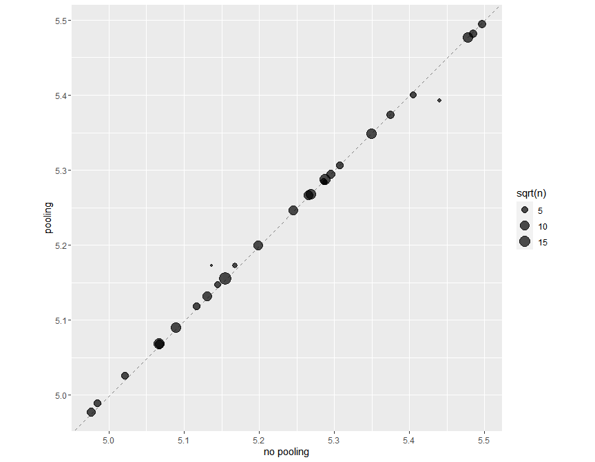

```
#> Warning: Removed 1 rows containing missing values (geom_point).
```

```r
glm_estimates %>%
  rename(`no pooling` = value) %>%
  left_join(
    mixed_estimates %>%
      rename(pooling = value), by = "level"
  ) %>%
  left_join(
    ames_train %>%
      count(Neighborhood) %>%
      mutate(level = as.character(Neighborhood))
  ) %>%
  ggplot(aes(`no pooling`, pooling, size = sqrt(n))) +
  geom_abline(color = "gray50", lty = 2) +
  geom_point(alpha = 0.7) +
  coord_fixed()
```

la mayoría de las estimaciones de los efectos en el vecindario son aproximadamente las mismas cuando comparamos la agrupación con ninguna agrupación. Sin embargo, los vecindarios con menos casas en ellos han sido arrastrados (ya sea hacia arriba o hacia abajo) hacia el efecto medio. Cuando usamos la agrupación, reducimos las estimaciones del efecto hacia la media porque no tenemos tanta evidencia sobre el precio en esos vecindarios

**HASHING DE CARACTERÍSTICAS**

```r
library(rlang)

ames_hashed <-
  ames_train %>%
  mutate(Hash = map_chr(Neighborhood, hash))

ames_hashed %>%
  select(Neighborhood, Hash)
```

| Neighborhood | Hash |
| --- | --- |
| North_Ames | 076543f71313e522efe157944169d919 |
| Briardale | b598bec306983e3e68a3118952df8cf0 |
| Briardale | b598bec306983e3e68a3118952df8cf0 |
| Briardale | b598bec306983e3e68a3118952df8cf0 |
| Northpark_Villa | 6af95b5db968bf393e78188a81e0e1e4 |
| Northpark_Villa | 6af95b5db968bf393e78188a81e0e1e4 |
| Sawyer_West | 5b8ac3fb32a9671d55da7b13c6e5ef49 |
| Sawyer_West | 5b8ac3fb32a9671d55da7b13c6e5ef49 |
| Sawyer | 2491e7eceb561d5a5f19abea49145c68 |
| Sawyer | 2491e7eceb561d5a5f19abea49145c68 |

[output cut: 2332 more lines]

La función genera un hash de 128 bits, lo que significa que hay posibles valores hash. Esto es ideal para algunas aplicaciones, pero no ayuda con el hashing de características de variables de alta cardinalidad (variables con muchos niveles). En el hashing de características, el número de hashes posibles es un hiperparámetro y es establecido por el desarrollador del modelo mediante el cálculo del módulo de los hashes enteros.rlang::hash()2^128

```r
ames_hashed %>%
  ## first make a smaller hash for integers that R can handle
  mutate(Hash = strtoi(substr(Hash, 26, 32), base = 16L),
         ## now take the modulo
         Hash = Hash %% 16) %>%
  select(Neighborhood, Hash)
```

| Neighborhood | Hash |
| --- | --- |
| North_Ames | 9 |
| Briardale | 0 |
| Briardale | 0 |
| Briardale | 0 |
| Northpark_Villa | 4 |
| Northpark_Villa | 4 |
| Sawyer_West | 9 |
| Sawyer_West | 9 |
| Sawyer | 8 |
| Sawyer | 8 |

[output cut: 2332 more lines]

Ahora, en lugar de los 28 vecindarios en nuestros datos originales o un número increíblemente grande de los hashes originales, tenemos dieciséis valores hash. Este método es muy rápido y eficiente en memoria, y puede ser una buena estrategia cuando hay una gran cantidad de categorías posibles.

```r
# install.packages("DALEXtra")
library(DALEXtra)
vip_features <- c("Neighborhood", "Gr_Liv_Area", "Year_Built",
                  "Bldg_Type", "Latitude", "Longitude")

vip_train <-
  ames_train %>%
  select(all_of(vip_features))

explainer_lm <-
  explain_tidymodels(
    lm_fit,
    data = vip_train,
    y = ames_train$Sale_Price,
    label = "lm + interactions",
    verbose = FALSE
  )

explainer_rf <-
  explain_tidymodels(
    rf_fit,
    data = vip_train,
    y = ames_train$Sale_Price,
    label = "random forest",
    verbose = FALSE
  )
```

```r
duplex <- vip_train[121,]
duplex
```

| Neighborhood | Gr_Liv_Area | Year_Built | Bldg_Type | Latitude | Longitude |
| --- | --- | --- | --- | --- | --- |
| North_Ames | 1040 | 1949 | Duplex | 42.03584 | -93.6089 |

```r
lm_breakdown <- predict_parts(explainer = explainer_lm, new_observation = duplex)
lm_breakdown
```

| variable | contribution | variable_name | variable_value | cumulative | sign | position | label |
| --- | --- | --- | --- | --- | --- | --- | --- |
| intercept | 5.2188031967 | intercept | 1 | 5.218803 | 1 | 8 | lm + interactions |
| Bldg_Type = 3 | -0.0834449655 | Bldg_Type | 3 | 5.135358 | -1 | 7 | lm + interactions |
| Gr_Liv_Area = 1040 | -0.0538728747 | Gr_Liv_Area | 1040 | 5.081485 | -1 | 6 | lm + interactions |
| Longitude = -93.608903 | -0.0554315133 | Longitude | -93.608903 | 5.026054 | -1 | 5 | lm + interactions |
| Year_Built = 1949 | -0.0412385339 | Year_Built | 1949 | 4.984815 | -1 | 4 | lm + interactions |
| Neighborhood = 1 | 0.0067078363 | Neighborhood | 1 | 4.991523 | 1 | 3 | lm + interactions |
| Latitude = 42.035841 | 0.0003983142 | Latitude | 42.035841 | 4.991921 | 1 | 2 | lm + interactions |
| prediction | 4.9919214598 |  |  | 4.991921 | X | 1 | lm + interactions |

Dado que este modelo lineal fue entrenado usando términos spline para latitud y longitud, la contribución al precio que se muestra aquí combina los efectos de todos sus términos spline individuales. La contribución aquí es en términos de la característica original, no de las características derivadas de spline.LongitudeLongitude

```r
rf_breakdown <- predict_parts(explainer = explainer_rf, new_observation = duplex)
rf_breakdown
```

| variable | contribution | variable_name | variable_value | cumulative | sign | position | label |
| --- | --- | --- | --- | --- | --- | --- | --- |
| intercept | 5.21839955 | intercept | 1 | 5.218400 | 1 | 8 | random forest |
| Gr_Liv_Area = 1040 | -0.07271341 | Gr_Liv_Area | 1040 | 5.145686 | -1 | 7 | random forest |
| Year_Built = 1949 | -0.07572694 | Year_Built | 1949 | 5.069959 | -1 | 6 | random forest |
| Bldg_Type = 3 | -0.03121580 | Bldg_Type | 3 | 5.038743 | -1 | 5 | random forest |
| Longitude = -93.608903 | -0.02970124 | Longitude | -93.608903 | 5.009042 | -1 | 4 | random forest |
| Latitude = 42.035841 | -0.03284293 | Latitude | 42.035841 | 4.976199 | -1 | 3 | random forest |
| Neighborhood = 1 | -0.00803427 | Neighborhood | 1 | 4.968165 | -1 | 2 | random forest |
| prediction | 4.96816495 |  |  | 4.968165 | X | 1 | random forest |

```r
predict_parts(explainer = explainer_rf, new_observation = duplex,
              order = lm_breakdown$variable_name)
```

| variable | contribution | variable_name | variable_value | cumulative | sign | position | label |
| --- | --- | --- | --- | --- | --- | --- | --- |
| intercept | 5.218399551 | intercept | 1 | 5.218400 | 1 | 8 | random forest |
| Bldg_Type = 3 | -0.028017960 | Bldg_Type | 3 | 5.190382 | -1 | 7 | random forest |
| Gr_Liv_Area = 1040 | -0.066812857 | Gr_Liv_Area | 1040 | 5.123569 | -1 | 6 | random forest |
| Longitude = -93.608903 | -0.017605368 | Longitude | -93.608903 | 5.105963 | -1 | 5 | random forest |
| Year_Built = 1949 | -0.096921211 | Year_Built | 1949 | 5.009042 | -1 | 4 | random forest |
| Neighborhood = 1 | 0.001975383 | Neighborhood | 1 | 5.011018 | 1 | 3 | random forest |
| Latitude = 42.035841 | -0.042852586 | Latitude | 42.035841 | 4.968165 | -1 | 2 | random forest |
| prediction | 4.968164952 |  |  | 4.968165 | X | 1 | random forest |

```r
shap_duplex <-
  predict_parts(explainer = explainer_rf,
                new_observation = duplex,
                type = "shap",
                B = 20)
```

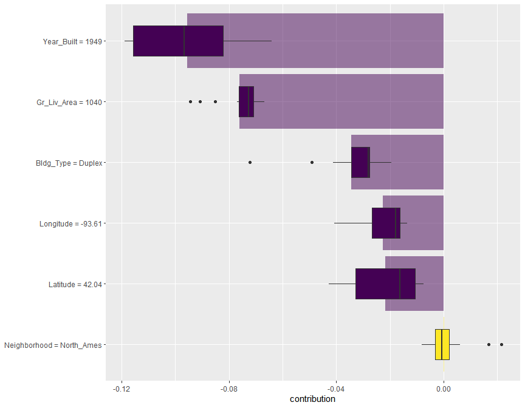

```r
library(forcats)
shap_duplex %>%
  group_by(variable) %>%
  mutate(mean_val = mean(contribution)) %>%
  ungroup() %>%
  mutate(variable = fct_reorder(variable, abs(mean_val))) %>%
  ggplot(aes(contribution, variable, fill = mean_val > 0)) +
  geom_col(data = ~distinct(., variable, mean_val),
           aes(mean_val, variable),
           alpha = 0.5) +
  geom_boxplot(width = 0.5) +
  theme(legend.position = "none") +
  scale_fill_viridis_d() +
  labs(y = NULL)
```

```r
big_house <- vip_train[1177,]
big_house
```

| Neighborhood | Gr_Liv_Area | Year_Built | Bldg_Type | Latitude | Longitude |
| --- | --- | --- | --- | --- | --- |
| Gilbert | 1804 | 1999 | OneFam | 42.05919 | -93.63907 |

```r
shap_house <-
  predict_parts(explainer = explainer_rf,
                new_observation = big_house,
                type = "shap",
                B = 20)
```

Usando DALEX, calculamos este tipo de importancia variable a través de la función.model_parts()

```r
vip_lm <- model_parts(explainer_lm, loss_function = loss_root_mean_square)
vip_rf <- model_parts(explainer_rf, loss_function = loss_root_mean_square)
```

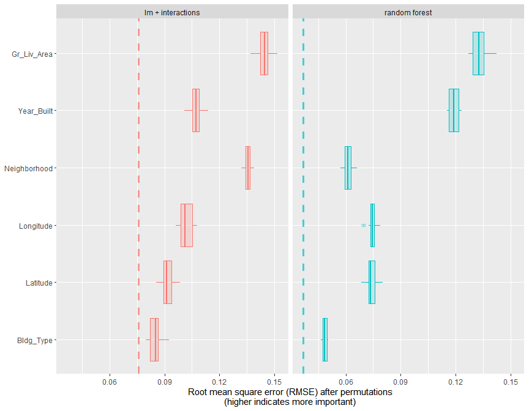

```r
ggplot_imp <- function(...) {
  obj <- list(...)
  metric_name <- attr(obj[[1]], "loss_name")
  metric_lab <- paste(metric_name,
                      "after permutations\n(higher indicates more important)")

  full_vip <- bind_rows(obj) %>%
    filter(variable != "_baseline_")

  perm_vals <- full_vip %>%
    filter(variable == "_full_model_") %>%
    group_by(label) %>%
    summarise(dropout_loss = mean(dropout_loss))

  p <- full_vip %>%
    filter(variable != "_full_model_") %>%
    mutate(variable = fct_reorder(variable, dropout_loss)) %>%
    ggplot(aes(dropout_loss, variable))
  if(length(obj) > 1) {
    p <- p +
      facet_wrap(vars(label)) +
      geom_vline(data = perm_vals, aes(xintercept = dropout_loss, color = label),
                 size = 1.4, lty = 2, alpha = 0.7) +
      geom_boxplot(aes(color = label, fill = label), alpha = 0.2)
  } else {
    p <- p +
      geom_vline(data = perm_vals, aes(xintercept = dropout_loss),
                 size = 1.4, lty = 2, alpha = 0.7) +
      geom_boxplot(fill = "#91CBD765", alpha = 0.4)

  }
  p +
    theme(legend.position = "none") +
    labs(x = metric_lab,
         y = NULL,  fill = NULL,  color = NULL)
}

ggplot_imp(vip_lm, vip_rf)
```